# S6 : Environmental data in R

Marine Ecological Modelling  
Global Climate Change

#### S6 : Environmental data in R

author: Jorge Assis  
contact: jmassis@ualg.pt  
code: github.com/jorgeassis  
tweets: twitter.com/jorgemfassis  
journal: [medium.com/theMarineDataScientist](https://medium.com/themarinedatascientist)

##### Environmental data [!]

In ecological modelling we often aim to understand how environment is shaping biodiversity patterns. Raster layers can be produced with temporal data (monthly) to generate more biologically meaningful variables.

```r
# always set a working directory
setwd(".")

# all packages needed and functions in external source file
source("sourceFunctions.R")
```

###### Terrestrial environmental layers : worldclim

Provided in different spatial resolutions. Check ?getData and https://www.worldclim.org/bioclim for more information.

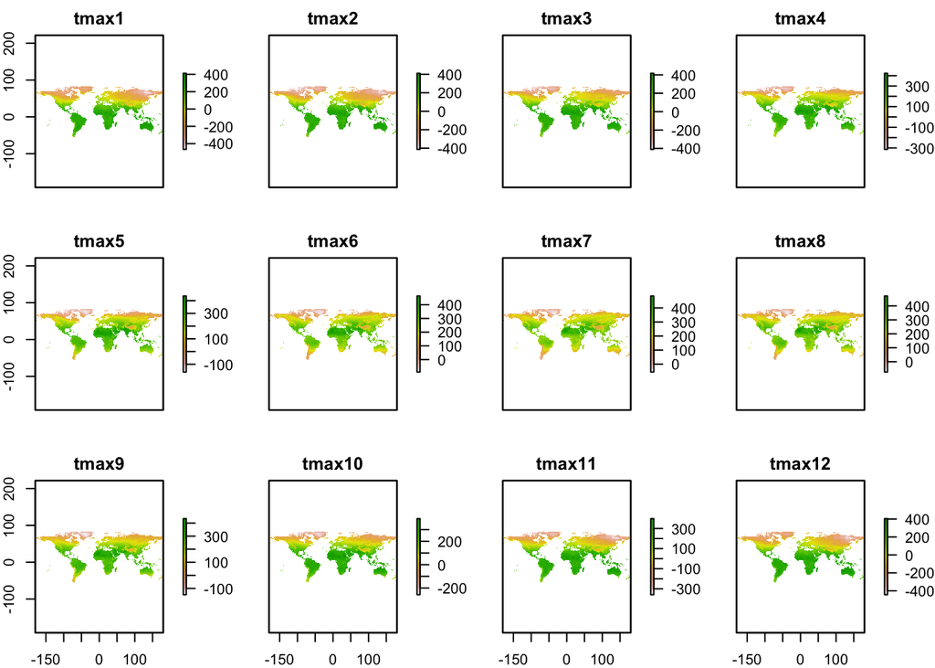

```r
# get terrestrial climate
airTempMaxMonths <- getData("worldclim", var="tmax", res=10, download=T, path=tempdir(check = FALSE))
plot(airTempMaxMonths)
```

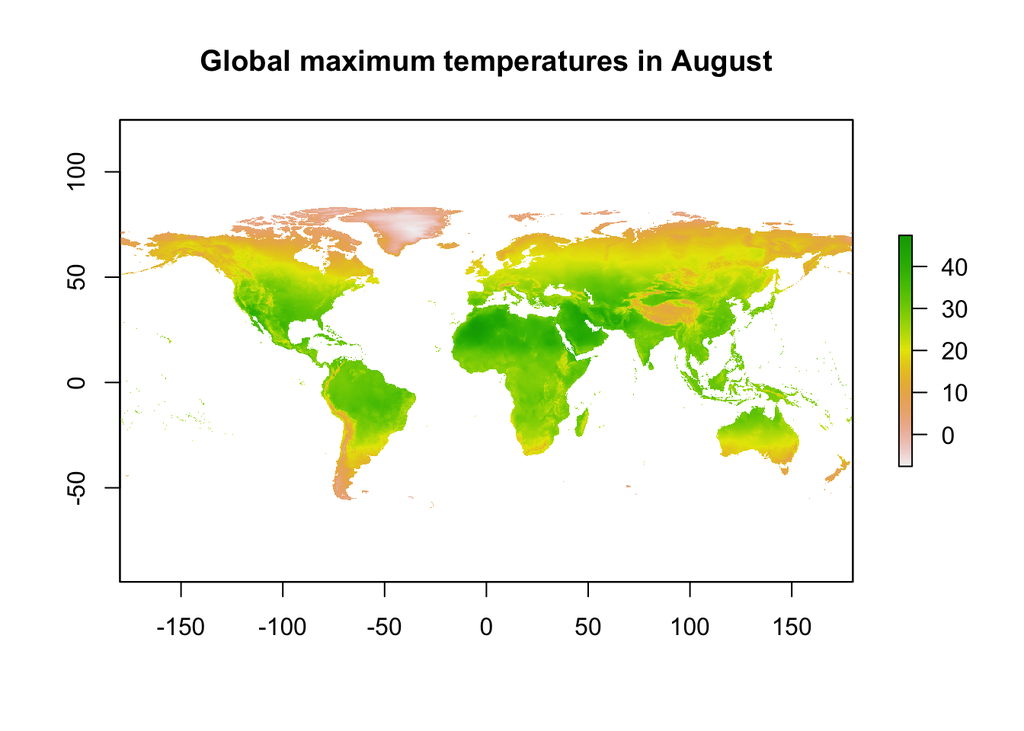

```r
# worldClim data has a scale factor of 10
airTempMaxMonths <- airTempMaxMonths / 10
plot( subset(airTempMaxMonths,8) , main="Global maximum temperatures in August")
```

```r
# Notes
# Valid names in worldclim are 'tmin', 'tmax', 'prec' and 'bio'.
# Valid resolutions are 0.5, 2.5, 5, and 10 (minutes of a degree). In the case of res=0.5, you must also provide a lon and lat argument for a tile. In all cases there are 12 (monthly) files for each variable except for 'bio' which contains 19 files. Check https://www.worldclim.org/bioclim for more information.
```

###### Marine environmental layers : Bio-ORACLE [!]

```r
# list all layers for the present
layerCodes <- list_layers( datasets = "Bio-ORACLE")
colnames(layerCodes)
```

```
##  [1] "dataset_code"               "layer_code"
##  [3] "name"                       "description"
##  [5] "terrestrial"                "marine"
##  [7] "freshwater"                 "cellsize_equalarea"
##  [9] "cellsize_lonlat"            "units"
## [11] "primary_type"               "primary_spatial_resolution"
## [13] "primary_source"             "start_year"
## [15] "start_month"                "start_day"
## [17] "end_year"                   "end_month"
## [19] "end_day"                    "derivation"
## [21] "month"                      "is_surface"
## [23] "version"
```

```r
head(layerCodes[,c("layer_code","name")])
```

```
##      layer_code                     name
## 69   BO_calcite           Calcite (mean)
## 70   BO_chlomax  Chlorophyll A (maximum)
## 71  BO_chlomean     Chlorophyll A (mean)
## 72   BO_chlomin  Chlorophyll A (minimum)
## 73 BO_chlorange    Chlorophyll A (range)
## 74  BO_cloudmax Cloud fraction (maximum)
```

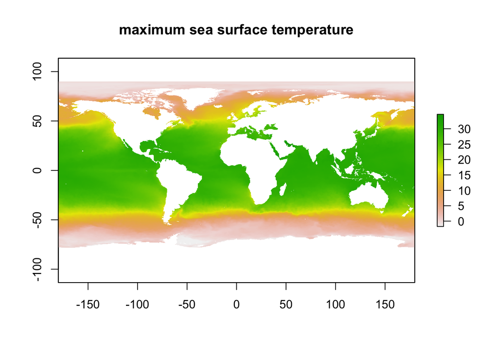

```r
# load layer of maximum sea surface temperature (ss)
maximumThermalConditions <- load_layers("BO2_tempmax_ss")
plot(maximumThermalConditions, main="maximum sea surface temperature")
```

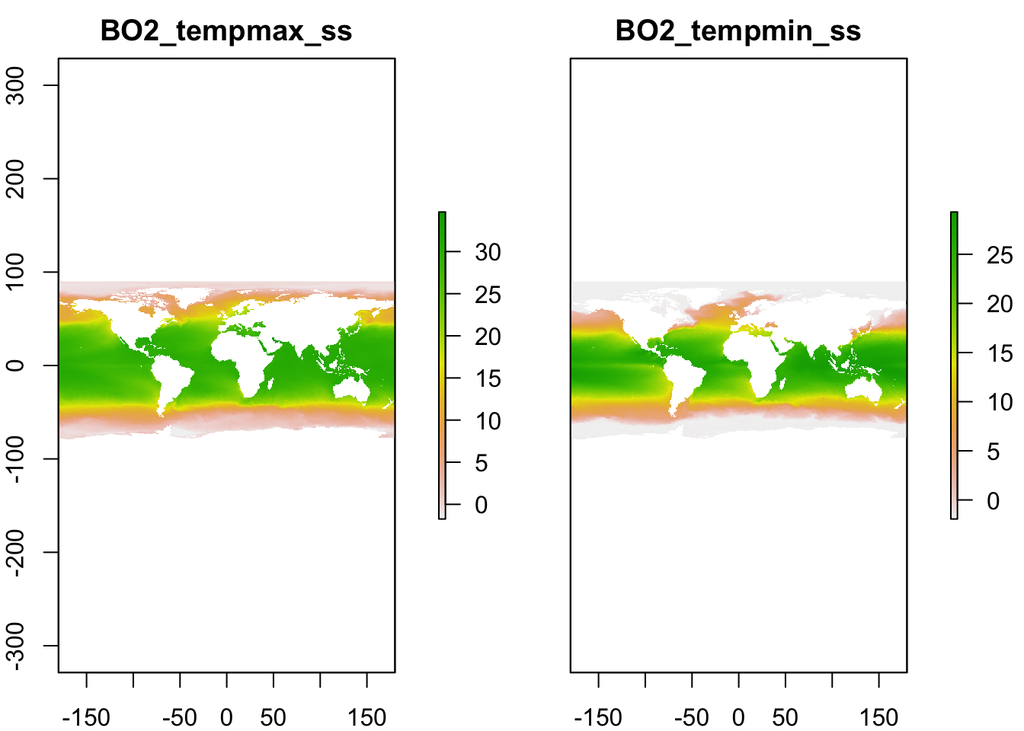

```r
# load layers of sea surface temperatures (max. and min.)
thermalConditions <- load_layers(c("BO2_tempmax_ss", "BO2_tempmin_ss"))
plot(thermalConditions)
```

```r
# list all layers for the future
layerCodesFuture <- list_layers_future( datasets = "Bio-ORACLE")
head(layerCodesFuture[,c("layer_code","scenario","year")])
```

```
##             layer_code scenario year
## 1 BO_A1B_2100_salinity      A1B 2100
## 2   BO_A1B_2100_sstmax      A1B 2100
## 3  BO_A1B_2100_sstmean      A1B 2100
## 4   BO_A1B_2100_sstmin      A1B 2100
## 5 BO_A1B_2100_sstrange      A1B 2100
## 6 BO_A1B_2200_salinity      A1B 2200
```

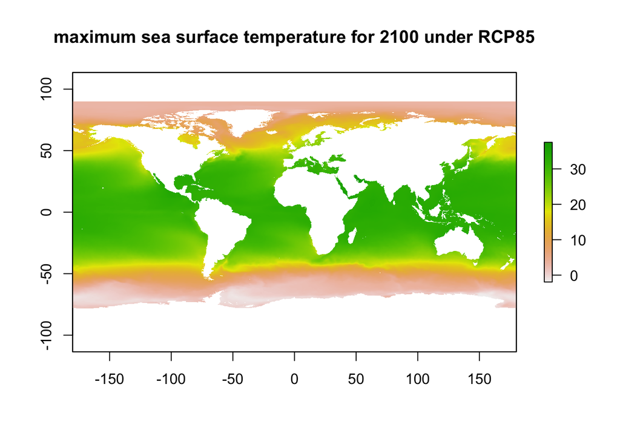

```r
# load layer of maximum sea surface temperature projected for 2100 under RCP85
maximumThermalConditions <- load_layers("BO2_RCP85_2100_templtmax_ss")
plot(maximumThermalConditions, main="maximum sea surface temperature for 2100 under RCP85")
```

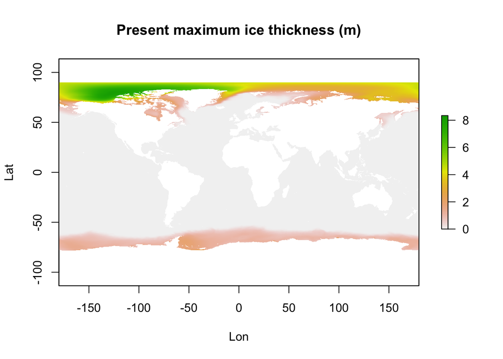

```r
# plot ice for the present
iceThickMinPresent <- load_layers("BO2_icethickltmax_ss")
plot(iceThickMinPresent, axes=TRUE, main="Present maximum ice thickness (m)" , ylab="Lat", xlab="Lon")
```

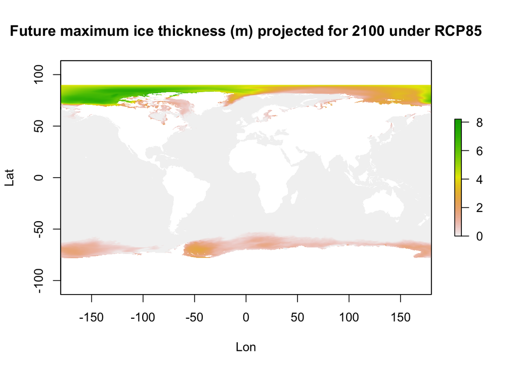

```r
# plot ice for the future
iceThickMaxRCP85 <- load_layers("BO2_RCP85_2100_icethickmax_ss")
plot(iceThickMaxRCP85, axes=TRUE, main="Future maximum ice thickness (m) projected for 2100 under RCP85" , ylab="Lat", xlab="Lon")
```

###### Challenge 6.1

The main objetive of this challenge is to **plot** the maximum sea surface temperature in Europe for the year 2100 under two contrasting scenarios of climate change (RCP26 and RCP85)

```r
# packages, data and functions needed to accomplish the challenge
source("sourceFunctions.R")

# Bio-ORACLE layer:
# Sea water temperature (maximum)

# European coastline extent
# xmin = -15
# xmax = 40
# ymin = 25
# ymax = 70.5

list_layers(datasets = "Bio-ORACLE")
list_layers_future(datasets = "Bio-ORACLE")
View()
load_layers()
extent(object)
crop(object)
plot(object)
```

###### Challenge 6.2

The main objetive of this challenge is to **plot** the difference in global maximum sea surface temperature between the present and the year 2100 under two contrasting scenarios of climate change (RCP26 and RCP85)

```r
# packages, data and functions needed to accomplish the challenge
source("sourceFunctions.R")

# Bio-ORACLE layer:
# Sea water temperature (maximum)

list_layers(datasets = "Bio-ORACLE")
list_layers_future(datasets = "Bio-ORACLE")
View()
load_layers()
plot(object)
```

###### Challenge 6.3

The main objetive of this challenge is to **plot** the difference in sea ice thickness between the present and the year 2100 under two contrasting scenarios of climate change (RCP26 and RCP85).

```r
# packages, data and functions needed to accomplish the challenge
source("sourceFunctions.R")

# Bio-ORACLE layer:
# Sea ice thickness (maximum)

list_layers(datasets = "Bio-ORACLE")
list_layers_future(datasets = "Bio-ORACLE")
View()
load_layers()
plot(object)
```

###### Challenge 6.4

The main objetive of this challenge is to **plot** the difference in sea temperature between the surface and bottom layers of the ocean.

```r
# packages, data and functions needed to accomplish the challenge
source("sourceFunctions.R")

# Bio-ORACLE layers:
# Sea water temperature (maximum)
# Sea water temperature (maximum at mean depth)

list_layers(datasets = "Bio-ORACLE")
View()
load_layers()
plot(object)
```

###### Challenge 6.5

The main objetive of this assignment is to **extract** the environmental use (values) of the mediterranean coral Paramuricea clavata for the present. Use GBIF data for this assignment.

```r
# packages, data and functions needed to accomplish the challenge
source("sourceFunctions.R")

# Bio-ORACLE layers:
# Dissolved oxygen concentration (mean at mean depth)
# Sea water temperature (maximum at mean depth)
# Sea water temperature (minimum at mean depth)
# Primary production (mean at mean depth)
# Sea water salinity (mean at mean depth)

getOccurrencesGBIF("Paramuricea clavata")
list_layers(datasets = "Bio-ORACLE")
View()
load_layers()
colnames(object)
extract(object)
summary(object)
hist(object)
```

###### Challenge 6.6 [see solution for challenge 3.9]

The main objetive of this challenge is to **reclassify** a set of environmental **rasters** and plot the potential habitat of a marine forest species (Saccorhiza polyschides) in European coastlines for the present and the future (year 2100 RCP 85) using a mechanistic approach (i.e., process based model). Compare ranges between time periods.

```r
# Suitable conditions** set by:
# Light > 3
# Salinity > 10
# Max. Temp. < 20.5
# Min. Temp. > 5

# European coastline extent
# xmin = -15
# xmax = 40
# ymin = 25
# ymax = 70.5

# Tasks to accomplish challenge 6.6
# 1. Get bio-ORACLE layers for the present and the future:
# Light at bottom (mean at maximum depth)   **
# Sea water salinity (minimum)
# Sea water temperature (minimum)
# Sea water temperature (maximum)
# ** There is no proection for the future so assume that light will not change.

# 2. Reclassify each raster so that suitable meet the consition as "1" and unsuitable as "0"
# 3. Multiply all layers considering the two groups of layers (present and the future)
# 4. Crop the resulting layers to the European region
# 5. Plot and compare the resulting layers

# packages, data and functions needed to accomplish the challenge
source("sourceFunctions.R")

list_layers(datasets = "Bio-ORACLE")
list_layers_future(datasets = "Bio-ORACLE")
load_layers()
View()
data.frame()
reclassify()
crop(object,extent(xmin,xmax,ymin,ymax))
plot(object)
```

##### Mismatch of spatial resolutions between different datasets

For specific modelling approches, layers must match in terms of extent and resolution.

```r
dtmEurope <- raster("Data/rasterLayers/dtmEurope.tif")
res(dtmEurope)
```

```
## [1] 0.008333140 0.008332948
```

```r
extent(dtmEurope)
```

```
## class      : Extent
## xmin       : -15.00382
## xmax       : 45.00312
## ymin       : 30.00278
## ymax       : 47.50197
```

```r
globalThermalConditions <- load_layers("BO2_tempmax_ss")
res(globalThermalConditions)
```

```
## [1] 0.08333333 0.08333333
```

```r
extent(globalThermalConditions)
```

```
## class      : Extent
## xmin       : -180
## xmax       : 180
## ymin       : -90
## ymax       : 90
```

```r
predictorsModelling <- stack(dtmEurope,globalThermalConditions)
```

```
## Error in compareRaster(x): different extent
```

Spatial interpolation may provide a good approch to make layers match in extent and resolution.

```r
dtmEurope <- raster("Data/rasterLayers/dtmEurope.tif")
europeThermalConditions <- resample(globalThermalConditions,dtmEurope)
predictorsModelling <- stack(dtmEurope,europeThermalConditions)
```

##### Collinearity (high correlation) between variables [!]

Many statistical models have problems to fit stable parameters if two or more predictors are highly correlated, resulting in so-called multicollinearity issues.

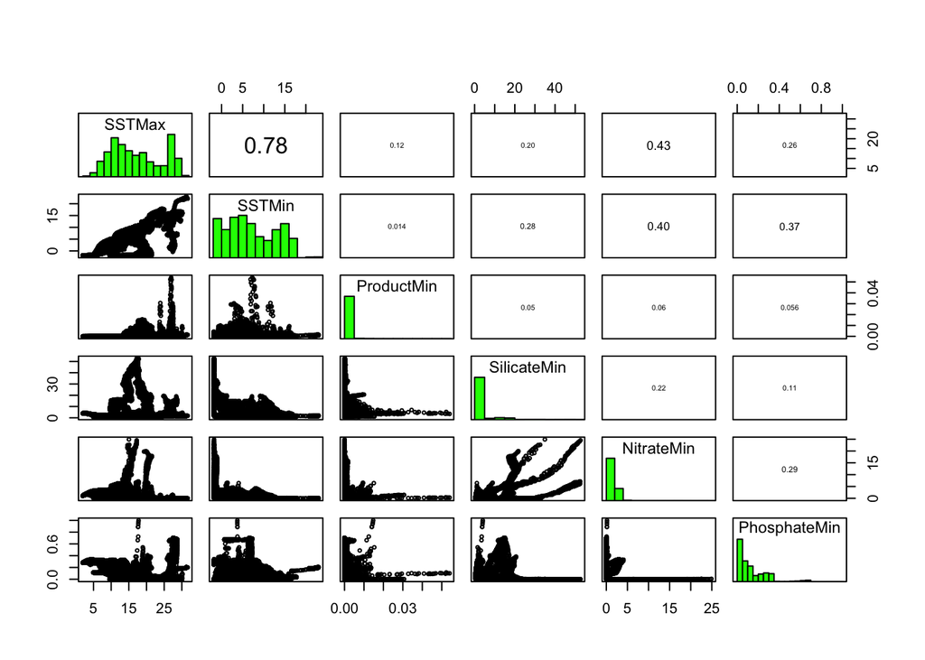

```r
# load layers from Bio-ORACLE
environmentalConditions <- load_layers(c("BO2_tempmax_ss", "BO2_tempmin_ss","BO2_ppmin_ss","BO2_silicatemin_ss","BO2_nitrateltmin_ss","BO2_phosphatemin_ss"))

# crop for the Mediterranean region
environmentalConditionsMed <- crop(environmentalConditions, extent(-15, 45, 25, 75))
names(environmentalConditionsMed) <- c("SSTMax","SSTMin","ProductMin","SilicateMin","NitrateMin","PhosphateMin")

# test for correlations
pairs(environmentalConditionsMed)
```

###### Challenge 6.7

The collinearity (high correlation) between your variables and region of interest.

```r
# packages, data and functions needed to accomplish the challenge
source("sourceFunctions.R")

list_layers(datasets = "Bio-ORACLE")
load_layers()
View()
crop(object,extent(xmin,xmax,ymin,ymax))
plot(object)
pairs(object)
```

R Markdown tutorial developed by Jorge Assis under the International License [[CC BY 4.0]](https://creativecommons.org/licenses/by/4.0/). When using, copying or modifying, the attribution citation should be **Assis, J. (2020) Marine Ecological Modelling and Global Climate Change. theMarineDatasSientist**.